# A 4 GB Laptop GPU Beats a 6-Core CPU by 4.3x on Gemma 4

[figure not shown]

This article compares two ways of serving the same small language model on the same laptop: CPU-only, and on the 4 GB GTX 1650 Ti sitting in the same chassis. The payload is byte-identical on both arms and the command lines differ by a single flag. The card takes decode by **4.3x**.

The repository is at https://github.com/xbill9/gemma4-dev

#### What Is Being Compared?

One machine, a Lenovo Yoga 9 15IMH5 laptop — Intel Core i7-10750H with a GTX 1650 Ti (Max-Q) in the same chassis. Two arms:

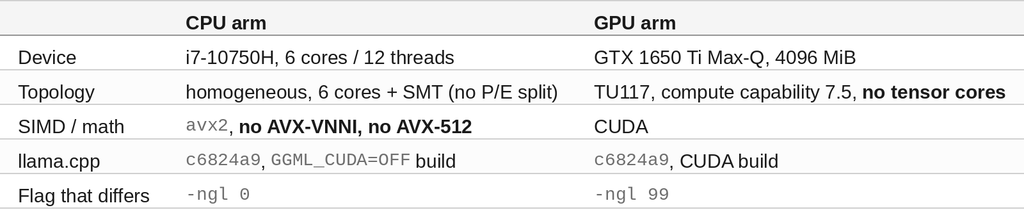

Everything else matches, and that is the whole exercise:

```
-m gemma-4-E2B_q4_0-it.gguf --host 127.0.0.1 --port 8080 \
  -ngl {0|99} -c 8192 -ctk f16 -ctv f16 -fa 1 -t 4 -tb 8 --parallel 1 --metrics
```

The model is `google/gemma-4-E2B-it-qat-q4_0-gguf`, a 3.35 GB quantization-aware GGUF. The two arms were run alternately against the same endpoint, CPU first, with a fixed 120 second cooldown between them.

#### The Result

Eight cells: four prompt lengths by two output lengths, three repeats each, concurrency 1. Decode is client-side inter-token rate measured off the SSE stream, which is the only decode statistic both arms can produce.

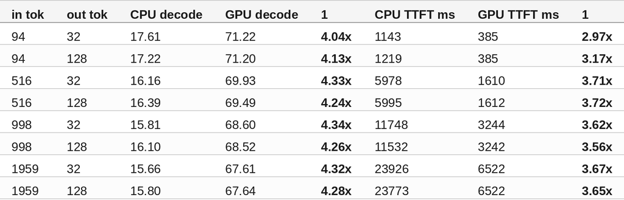

Medians over the eight cells: decode **4.27x**, prefill **3.63x**, end-to-end **3.81x**.

#### Is That Difference Real?

Within-cell spread over three repeats was **6.29%** worst case on the CPU arm and **0.84%** on the GPU arm. The decode ratio spans 4.04x to 4.34x across every cell. The effect is an order of magnitude clear of the noise, which is the only reason it is worth reporting at all.

#### Decode Is Flat, Prefill Is Linear

Look down the decode columns rather than across them.

CPU decode moves from 17.61 to 15.66 tok/s. GPU decode moves from 71.22 to 67.61. Across a **21x range of prompt length**, on both arms, decode barely moves. TTFT over the same range goes from 1143 ms to 23926 ms on the CPU and 385 ms to 6522 ms on the GPU — linear in the prompt.

That is the expected shape stated twice. Decode reads the whole model per token and is bandwidth-bound; prefill multiplies through the prompt and is compute-bound. An accelerator helps both, but it helps them for different reasons, and a benchmark that quotes one number hides that.

The decode *ratio* also climbs with context — 4.04x at 94 tokens, 4.34x at 998. The CPU arm loses ground as the KV cache grows and the GPU arm barely does.

#### How Does 3.35 GB Fit in a 4 GB Card?

It does not have to. With the model loaded and serving, the card holds **1598 MiB**.

The artifact is only 32% Q4_0. Both embedding tensors are Q6_K and account for 2.257 GB of the 3.334 GB of tensor bytes, and the largest of them — `per_layer_token_embd`, at 1.93 GB, 58% of the file — is created with `TENSOR_READ_LAZY` in llama.cpp's `src/models/gemma4.cpp` and served by `GGML_OP_GET_ROWS` straight out of the mmap. A few rows are touched per token. It never goes to the card.

What is resident is the ~1.08 GB Q4_0 transformer body, which is what decode reads every token, plus about 60 MiB of KV cache and the compute buffers.

The same mechanism costs something on the CPU arm instead of saving something. `RssAnon` there is 1,202,152 kB, because llama.cpp repacks Q4_0 weights into an interleaved layout for its AVX2 kernels, copying the body out of the mmap into anonymous memory.

So the headline works because of the checkpoint's shape, not in spite of the card's size. A 4 GB GPU from 2021 is not too small for this model. It is roughly 2.5x larger than it needs to be.

#### What Was Controlled

The two arms differ by one flag. Everything else was held equal deliberately, and checked rather than assumed:

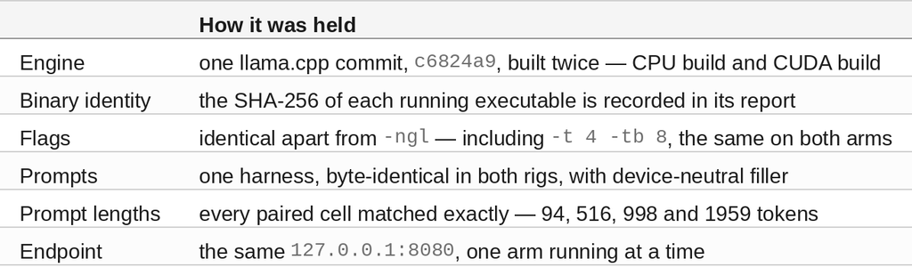

That last row is the one worth dwelling on. Both arms serve the same model on the same port, so an HTTP response says nothing about which device produced it. **The device is therefore read from the running process rather than taken from a label** — `/proc/<pid>/exe` for the binary, `/proc/<pid>/maps` for the ggml backends actually loaded, `/proc/<pid>/cmdline` for the real `-ngl` — and that attestation is stamped into every report beside the numbers.

`maps` rather than `ldd`, because llama.cpp `dlopen`s its backends: a CUDA backend can be absent from `ldd` output and present in the running process. The verdict needs a GPU backend mapped in **and** layers assigned to it, since a CUDA build running `-ngl 0` computes on the CPU but is not a clean CPU arm — the device is initialised and large prefill batches can still land on it. The CPU arm hides the device from the process entirely rather than trusting `-ngl 0`.

#### What Was Not Controlled

Read the 4x as real and anything under about 7% as nothing.

- **Order and thermals.** The CPU arm ran first and saturated every thread. The i7-10750H and the Max-Q card share one thermal envelope, so the GPU arm started on a warm package. The 120 second cooldown was sized, not measured. This machine throttles harder than that implies — an identical CPU config re-run cold later moved 19% on decode — so no CPU absolute here should be read to better than about 20%; the 4x ratio survives only because the arms were interleaved. If this biases anything it understates the GPU arm.
- **Page cache.** The GGUF was hot for both arms. This says nothing about cold start, and the lazy-embedding claim above is inferred from the source and the resident-memory figures rather than from a dropped-cache experiment.
- **CPU affinity.** Nothing was pinned, and how much that costs is **open**. An earlier `llama-bench` sweep appeared to show affinity worth 1.61x on prefill via straggler cores — that sweep was later found to describe a hybrid P/E die this machine does not have, and has been withdrawn. On the real homogeneous 6-core part a spot-check could not separate pinning from thermal drift, so no upper bound on the prefill gap is claimed. Decode is unaffected — thread count is a weak lever there — so the 4.27x stands.
- **Concurrency.** Single stream throughout, `--parallel 1`.

#### Summary

- GPU decode is **4.27x** the CPU arm, 4.04x to 4.34x across every cell
- GPU prefill is **3.63x**, with the CPU arm left unpinned (what pinning is worth on this part is unresolved)
- End-to-end is **3.81x**
- Decode is flat in context on both arms; TTFT is linear in it on both
- The model needs **1598 MiB** of the card, because 58% of the file is a lazily read embedding table that never leaves host memory

Scope: one laptop, one GGUF, llama.cpp `c6824a9` built twice from the same commit, eight paired cells, three repeats per cell, concurrency 1, CPU arm first with a 120 second cooldown. CPU affinity was not set on either arm and the page cache was warm for both.